# Class Activity, January 26

In this activity, you will practice using and interpreting a fitted regression line. We will work with data on 116 sparrows, which were observed on Kent Island, New Brunswick. For each sparrow, we have information including:

- *Weight*: the weight of the sparrow (in grams)
- *WingLength*: the sparrow’s wing length (in mm)

This data is included in the `Stat2Data` package (the R package for our class textbook).

## Setup

As with all class activities, there is nothing you will need to submit. However, in case it helps you work on the questions, an R Markdown template is provided for you: [activity template](https://sta112-f21.github.io/class_activities/ca_lecture_7_template.Rmd)

## Questions

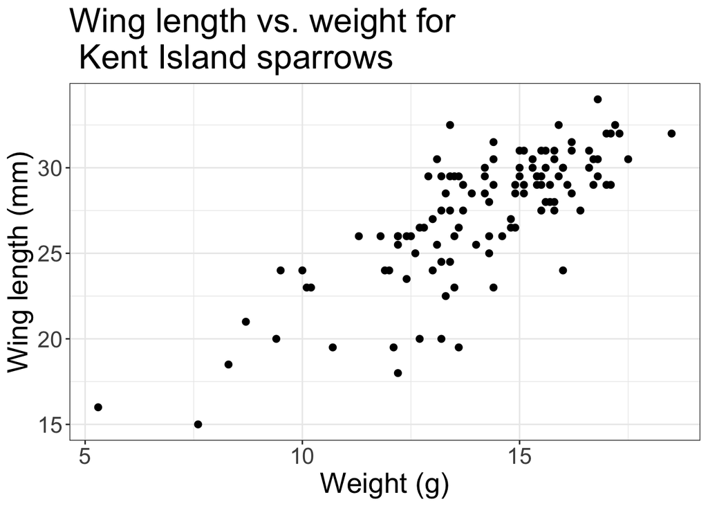

1. Based on the plot, is linear regression an appropriate choice for modeling the relationship between weight and wing length?

We now fit a linear regression, with weight as the explanatory variable and wing length as the response. The equation of the fitted model is

$\widehat{\text{wing length}} = 8.755 + 1.313 \ \text{weight}$